# LAD Homework1

# Part 1. Exploratory Data Analysis

## Part 1.1 Compute summary statistics

### load library

```r
library(here)
library(tidyverse)
library(skimr)
library(magrittr)
library(Hmisc)
library(summarytools)
library(gmodels)
```

### read csv file

```r
camp_primary <- read_csv(here("homework1", "camp_primary.csv"), col_names = T)
```

```r
camp_primary %>%
  skim()
```

```
── Data Summary ────────────────────────
                           Values
Name                       Piped data
Number of rows             6584
Number of columns          9
_______________________
Column type frequency:
  numeric                  9
________________________
Group variables            None

── Variable type: numeric ────────────────────────────────────────────────────────────
  skim_variable n_missing complete_rate    mean      sd     p0    p25   p50    p75
1 id                    0         1     530.    302.     1     266    538    793
2 age_rz                0         1       8.35    2.15   5       7      8     10
3 POSFEV               15         0.998   2.22    0.711  0.570   1.72   2.1    2.6
4 visitc                0         1      20.6    16.0    0       4     16     36
5 fdays                 0         1     624.    483.    -1     125    510   1092
6 gender                0         1       0.407   0.491  0       0      0      1
7 ethnic                0         1       0.586   0.978  0       0      0      1
8 trt                   0         1       0.909   0.830  0       0      1      2
9 visit                 0         1       5.42    2.87   1       3      5      8
     p100 hist
1 1041    ▇▇▇▇▇
2   13    ▆▇▃▆▂
3    5.88 ▃▇▂▁▁
4   48    ▇▅▅▂▅
5 1522    ▇▅▅▃▃
6    1    ▇▁▁▁▆
7    3    ▇▂▁▁▁
8    2    ▇▁▆▁▆
9   10    ▇▇▇▇▇
```

POSFEV has 15 missing values.

```r
## find those missing values
camp_primary %>%
  filter(is.na(POSFEV))
```

| id | age_rz | POSFEV | visitc | fdays | gender | ethnic | trt | visit |
| --- | --- | --- | --- | --- | --- | --- | --- | --- |
| 171 | 11 | NA | 48 | 1465 | 0 | 0 | 1 | 10 |
| 188 | 13 | NA | 40 | 1208 | 1 | 0 | 2 | 9 |
| 192 | 7 | NA | 4 | 120 | 1 | 0 | 0 | 3 |
| 228 | 9 | NA | 0 | -1 | 1 | 1 | 0 | 1 |
| 257 | 8 | NA | 4 | 125 | 1 | 0 | 0 | 3 |
| 317 | 6 | NA | 40 | 1198 | 0 | 0 | 2 | 9 |
| 414 | 10 | NA | 48 | 1435 | 0 | 0 | 2 | 10 |
| 509 | 9 | NA | 4 | 133 | 0 | 3 | 0 | 3 |
| 662 | 13 | NA | 48 | 1412 | 0 | 0 | 0 | 10 |
| 680 | 9 | NA | 16 | 540 | 0 | 2 | 0 | 5 |

[output cut: 5 more lines]

Drop missing values

```r
camp_primary %<>%
  filter(!is.na(POSFEV))

camp_primary %>%
  skim(POSFEV)
```

```
── Data Summary ────────────────────────
                           Values
Name                       Piped data
Number of rows             6569
Number of columns          9
_______________________
Column type frequency:
  numeric                  1
________________________
Group variables            None

── Variable type: numeric ────────────────────────────────────────────────────────────
  skim_variable n_missing complete_rate  mean    sd    p0   p25   p50   p75  p100
1 POSFEV                0             1  2.22 0.711 0.570  1.72   2.1   2.6  5.88
  hist
1 ▃▇▂▁▁
```

### labeling

```r
label(camp_primary$trt) <- "treatment group"
label(camp_primary$age_rz) <- "age at rz, years"
label(camp_primary$POSFEV) <- "post-bronchodilator FEV1 in liters"
label(camp_primary$visitc) <- "months since rz"
label(camp_primary$fdays) <- "days since rz"
label(camp_primary$gender) <- "gender"
label(camp_primary$ethnic) <- "ethnicity"
```

```r
camp_primary %<>%
  mutate(gender = factor(gender, levels = c("0", "1"),
                         labels = c("male", "female"))) %>%
  mutate(ethnic = factor(ethnic, levels = c("0", "1", "2", "3"),
                         labels = c("White", "Black", "Hispanic", "Other"))) %>%
  mutate(trt = factor(trt, levels = c("0", "1", "2"),
                         labels = c("placebo", "budesonide", "nedocromil")))
```

## Q1a

### create variable nobs “Number of observations”

```r
camp_primary <- camp_primary %>%
  group_by(id) %>%
  mutate(nobs=n()) %>%
  ungroup()

label(camp_primary$nobs) <- "number of observations"
```

### Summarize the number of follow-up visits that were completed by the 695 children

```r
camp_primary %>%
  group_by(id) %>%
  filter(visit == max(visit)) %>%
  ungroup() %>%
  summarise(obs = n(),
           mean_obs = mean(nobs),
           sd_obs = sd(nobs),
           min_obs = min(nobs),
           max_obs = max(nobs))
```

| obs | mean_obs | sd_obs | min_obs | max_obs |
| --- | --- | --- | --- | --- |
| 695 | 9.45 | 1.48 | 1 | 10 |

Summary of the number of follow-up visits that were completed by the 695 children:

mean = 9.45 (sd=1.48), min=1, max=10, N=695

### frequency table of the number of follow-up visits

```r
camp_primary_nobs <- camp_primary %>%
  group_by(id) %>%
  filter(visit == max(visit)) %>%
  ungroup()

camp_primary_nobs %>%
 summarytools::freq(nobs, order = "-freq", totals = FALSE)
```

```
Frequencies
camp_primary_nobs$nobs
Label: number of observations

             Freq   % Valid   % Valid Cum.   % Total   % Total Cum.
---------- ------ --------- -------------- --------- --------------
         1      3      0.43           0.43      0.43           0.43
         3      4      0.58           1.01      0.58           1.01
         2      6      0.86           1.87      0.86           1.87
         6      7      1.01           2.88      1.01           2.88
         4      8      1.15           4.03      1.15           4.03
         5      9      1.29           5.32      1.29           5.32
         7     16      2.30           7.63      2.30           7.63
         8     18      2.59          10.22      2.59          10.22
         9     73     10.50          20.72     10.50          20.72
        10    551     79.28         100.00     79.28         100.00
      <NA>      0                               0.00         100.00
```

## Q1b

Summarize the baseline characteristics (age, gender and ethnicity) of the children separately for each treatment group. Include the number of children receiving each treatment.

```r
camp_primary_nobs %>%
  group_by(trt) %>%
  summarise(obs = n(),
           mean_age = round(mean(age_rz), 2),
           sd_age = round(sd(age_rz), 2),
           min_age = min(age_rz),
           max_age = max(age_rz)) %>%
    ungroup()
```

| trt | obs | mean_age | sd_age | min_age | max_age |
| --- | --- | --- | --- | --- | --- |
| placebo | 275 | 8.33 | 2.17 | 5 | 13 |
| budesonide | 210 | 8.51 | 2.14 | 5 | 13 |
| nedocromil | 210 | 8.30 | 2.17 | 5 | 13 |

#### Two-way tabulation for gender and ethnicity

```r
## gender
with(camp_primary_nobs, CrossTable(trt, gender,
           digits = 2, prop.r = T, prop.c = T, prop.t = F,
           prop.chisq = F, format = "SPSS"))
```

```
   Cell Contents
|-------------------------|
|                   Count |
|             Row Percent |
|          Column Percent |
|-------------------------|

Total Observations in Table:  695

             | gender
         trt |     male  |   female  | Row Total |
-------------|-----------|-----------|-----------|
     placebo |      146  |      129  |      275  |
             |    53.09% |    46.91% |    39.57% |
             |    35.44% |    45.58% |           |
-------------|-----------|-----------|-----------|
  budesonide |      126  |       84  |      210  |
             |    60.00% |    40.00% |    30.22% |
             |    30.58% |    29.68% |           |
-------------|-----------|-----------|-----------|
  nedocromil |      140  |       70  |      210  |
             |    66.67% |    33.33% |    30.22% |
             |    33.98% |    24.73% |           |
-------------|-----------|-----------|-----------|
Column Total |      412  |      283  |      695  |
             |    59.28% |    40.72% |           |
-------------|-----------|-----------|-----------|
```

```r
## ethnicity
with(camp_primary_nobs, CrossTable(trt, ethnic,
           digits = 2, prop.r = T, prop.c = T, prop.t = F,
           prop.chisq = F, format = "SPSS"))
```

```
   Cell Contents
|-------------------------|
|                   Count |
|             Row Percent |
|          Column Percent |
|-------------------------|

Total Observations in Table:  695

             | ethnic
         trt |    White  |    Black  | Hispanic  |    Other  | Row Total |
-------------|-----------|-----------|-----------|-----------|-----------|
     placebo |      194  |       35  |       25  |       21  |      275  |
             |    70.55% |    12.73% |     9.09% |     7.64% |    39.57% |
             |    40.50% |    39.33% |    36.76% |    35.59% |           |
-------------|-----------|-----------|-----------|-----------|-----------|
  budesonide |      142  |       27  |       20  |       21  |      210  |
             |    67.62% |    12.86% |     9.52% |    10.00% |    30.22% |
             |    29.65% |    30.34% |    29.41% |    35.59% |           |
-------------|-----------|-----------|-----------|-----------|-----------|
  nedocromil |      143  |       27  |       23  |       17  |      210  |
             |    68.10% |    12.86% |    10.95% |     8.10% |    30.22% |
             |    29.85% |    30.34% |    33.82% |    28.81% |           |
-------------|-----------|-----------|-----------|-----------|-----------|
Column Total |      479  |       89  |       68  |       59  |      695  |
             |    68.92% |    12.81% |     9.78% |     8.49% |           |
-------------|-----------|-----------|-----------|-----------|-----------|
```

## Part 1.2a

Our analysis will focus on comparing pulmonary function over time, separately for each treatment group. In this section, you will explore the patterns of pulmonary function over time and determine a model to compare the trends in the mean pulmonary function over time across the three treatment groups.

1. Ignoring treatment assignment, create a figure displaying the association between postbronchodilator FEV1 and time, where the focus is to describe how the mean FEV1 changes over the 48 months of the primary CAMP study.

```r
# generate some summaries of POSFEV by visits for plotting
visitc.summaries <-
    camp_primary %>%
    group_by(visitc) %>%
    summarise(avgfev = mean(POSFEV),
              sdfev = sd(POSFEV),
              medfev = median(POSFEV),
              q75fev = quantile(POSFEV, 0.75),
              q25fev = quantile(POSFEV, 0.25))
print(visitc.summaries)
```

| visitc | avgfev | sdfev | medfev | q75fev | q25fev |
| --- | --- | --- | --- | --- | --- |
| 0 | 1.81 | 0.511 | 1.75 | 2.11 | 1.46 |
| 2 | 1.87 | 0.510 | 1.81 | 2.17 | 1.50 |
| 4 | 1.90 | 0.516 | 1.83 | 2.20 | 1.53 |
| 12 | 2.06 | 0.582 | 1.98 | 2.36 | 1.64 |
| 16 | 2.12 | 0.601 | 2.02 | 2.44 | 1.69 |
| 24 | 2.28 | 0.651 | 2.17 | 2.58 | 1.82 |
| 28 | 2.36 | 0.678 | 2.23 | 2.67 | 1.89 |
| 36 | 2.53 | 0.726 | 2.40 | 2.92 | 2.00 |
| 40 | 2.60 | 0.744 | 2.48 | 3.04 | 2.06 |
| 48 | 2.79 | 0.795 | 2.67 | 3.25 | 2.18 |

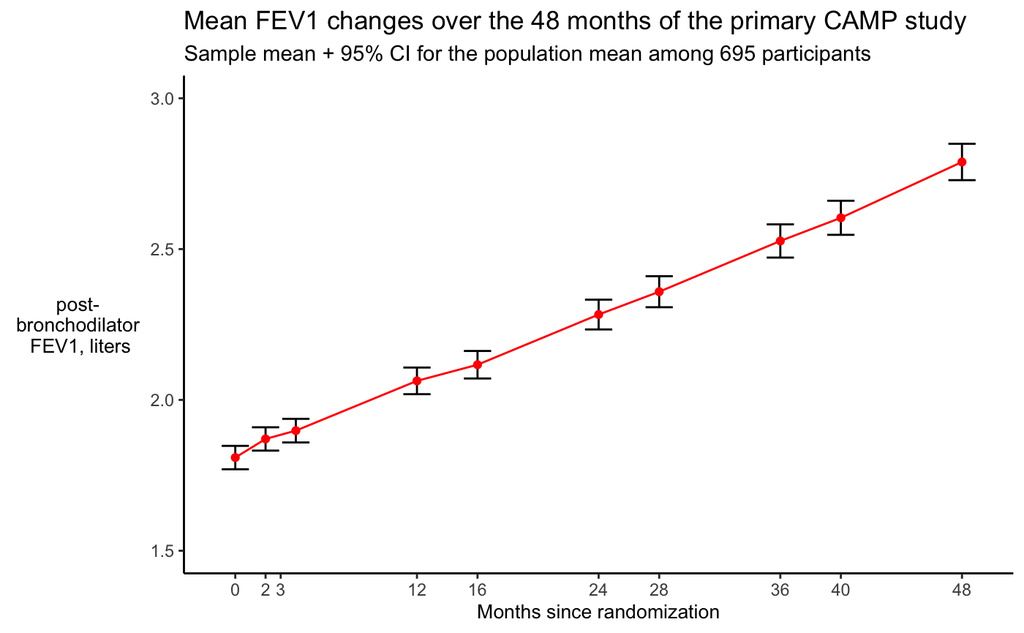

```r
# get the number of sample
n <- length(unique(camp_primary$id))

# Sample mean + 95% CI for the mean
visitc.summaries %>%
  ggplot() +
  geom_errorbar(aes(x = visitc, ymin = avgfev - 2*sdfev/sqrt(n),
                    ymax = avgfev + 2*sdfev/sqrt(n))) +
  geom_point(aes(x = visitc, y = avgfev), color = "red") +
  geom_line(aes(x = visitc, y = avgfev), color = "red") +
  scale_x_continuous(breaks = c(0, 2, 3, 12, 16, 24, 28, 36, 40, 48)) +
  ylim(1.5, 3) +
  theme_classic() +
  xlab("Months since randomization") +
  ylab("post-\n bronchodilator \n FEV1, liters") +
  ggtitle("Mean FEV1 changes over the 48 months of the primary CAMP study") +
  labs(subtitle = "Sample mean + 95% CI for the population mean among 695 participants") +
  theme(axis.title.y = element_text(angle = 0, vjust = 0.5, size = 10),
        axis.title.x = element_text(size = 10))
```

## Part 1.2b

Create a figure displaying the association between post-bronchodilator FEV1 and time separately in each treatment group. Allow the focus of your graph to describe how the mean FEV1 changes for each treatment group over the primary CAMP study period.

```r
# generate some summaries of POSFEV grouped by visits and treatment groups for plotting
trt.summaries <-
    camp_primary %>%
    group_by(visitc, trt) %>%
    summarise(avgfev = mean(POSFEV),
              sdfev = sd(POSFEV),
              medfev = median(POSFEV),
              q75fev = quantile(POSFEV, 0.75),
              q25fev = quantile(POSFEV, 0.25))
print(trt.summaries)
```

| visitc | trt | avgfev | sdfev | medfev | q75fev | q25fev |
| --- | --- | --- | --- | --- | --- | --- |
| 0 | placebo | 1.83 | 0.528 | 1.75 | 2.12 | 1.44 |
| 0 | budesonide | 1.85 | 0.484 | 1.79 | 2.10 | 1.51 |
| 0 | nedocromil | 1.75 | 0.513 | 1.69 | 2.08 | 1.38 |
| 2 | placebo | 1.87 | 0.521 | 1.77 | 2.17 | 1.48 |
| 2 | budesonide | 1.94 | 0.497 | 1.88 | 2.19 | 1.60 |
| 2 | nedocromil | 1.81 | 0.502 | 1.77 | 2.13 | 1.43 |
| 4 | placebo | 1.90 | 0.526 | 1.82 | 2.20 | 1.52 |
| 4 | budesonide | 1.95 | 0.506 | 1.90 | 2.22 | 1.62 |
| 4 | nedocromil | 1.85 | 0.509 | 1.80 | 2.18 | 1.46 |
| 12 | placebo | 2.08 | 0.607 | 1.98 | 2.35 | 1.61 |

[output cut: 20 more lines]

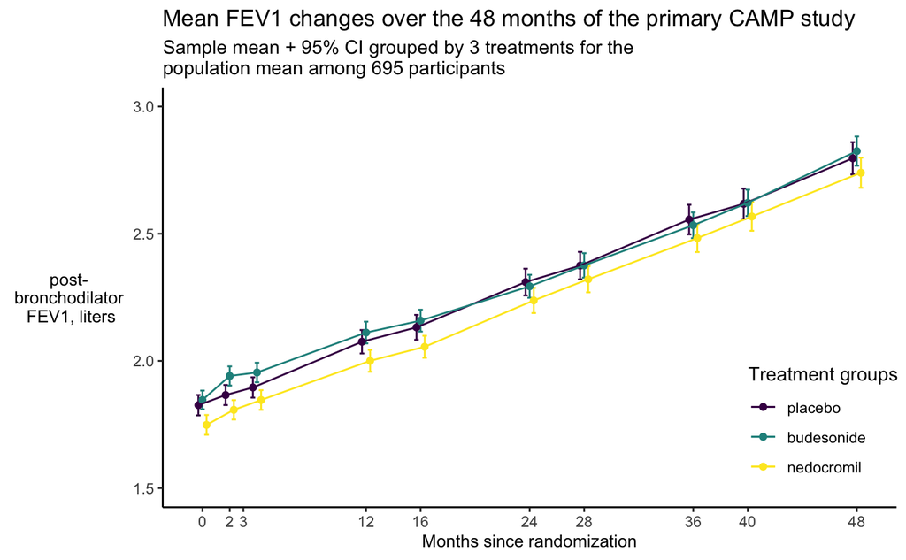

```r
# Sample mean + 95% CI for the mean grouped by treamtments
trt.summaries %>%
  ggplot() +
  geom_errorbar(aes(x = visitc, ymin = avgfev - 2*sdfev/sqrt(n),
                    ymax = avgfev + 2*sdfev/sqrt(n),
                    color = trt),
                width = 1,
                position = position_dodge(width=0.9)) +
  geom_point(aes(x = visitc, y = avgfev, color = trt),
             position = position_dodge(width=0.9)) +
  geom_line(aes(x = visitc, y = avgfev,
                group = trt, color = trt),
            position = position_dodge(width=0.9)) +
  scale_x_continuous(breaks = c(0, 2, 3, 12, 16, 24, 28, 36, 40, 48)) +
  ylim(1.5, 3) +
  theme_classic() +
  xlab("Months since randomization") +
  ylab("post-\n bronchodilator \n FEV1, liters") +
  ggtitle("Mean FEV1 changes over the 48 months of the primary CAMP study") +
  labs(subtitle = "Sample mean + 95% CI grouped by 3 treatments for the\npopulation mean among 695 participants") +
  theme(axis.title.y = element_text(angle = 0, vjust = 0.5, size = 10),
        axis.title.x = element_text(size = 10)) +
  theme(legend.position = c(0.9, 0.2)) +
  labs(color="Treatment groups") + ## legend's title
  scale_color_viridis_d() ## use color-blind friendly palettes
```

## Part 1.2c - Spaghetti plot

3. Ignoring treatment assignment, create a figure summarizing how the FEV1 changes over the study period among individual children within the trial.

```
`fun.y` is deprecated. Use `fun` instead.
```

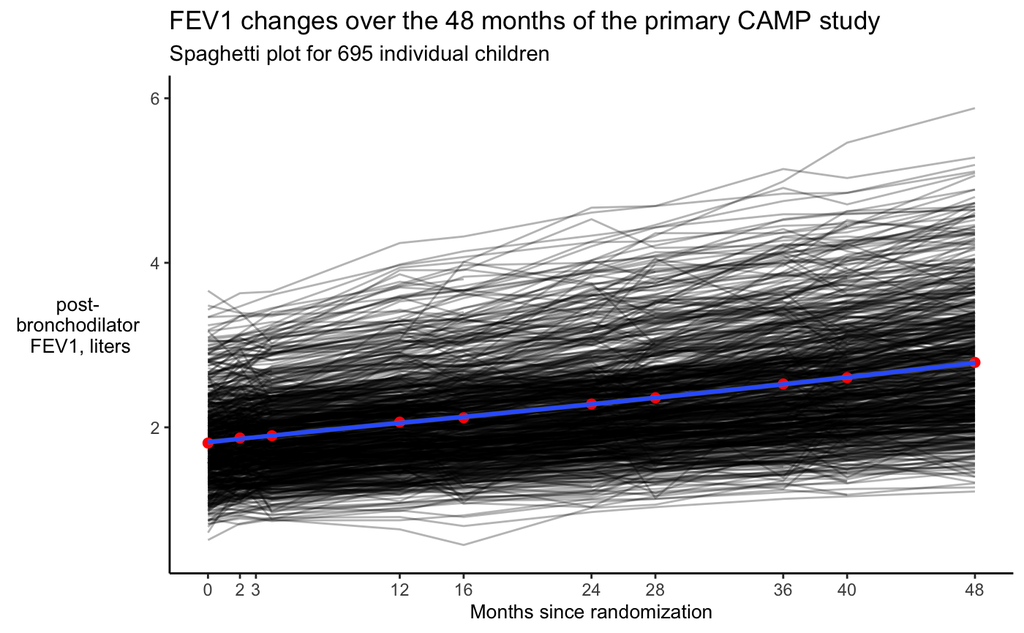

```r
camp_primary %>%
 ggplot() +
  geom_line(aes(group = id, x = visitc, y = POSFEV), alpha = 0.3) +
  scale_x_continuous(breaks = c(0, 2, 3, 12, 16, 24, 28, 36, 40, 48)) +
  ylim(0.5, 6) +
  theme_classic() +
  xlab("Months since randomization") +
  ylab("post-\n bronchodilator \n FEV1, liters") +
  ggtitle("FEV1 changes over the 48 months of the primary CAMP study") +
  labs(subtitle = "Spaghetti plot for 695 individual children") +
  theme(axis.title.y = element_text(angle = 0, vjust = 0.5, size = 10),
        axis.title.x = element_text(size = 10)) +
  stat_summary(fun.y = mean, geom = "point", lwd = 2, colour = "red",
               aes(x = visitc, y = POSFEV)) + ## add children average per visit
  stat_smooth(aes(group = 1, x = visitc, y = POSFEV)) ## add children mean lowess line
```

## Part 1.2d - Spaghetti plot by groups

4. Create a figure summarizing how the FEV1 changes over the study period among individual children from each treatment group

```
`fun.y` is deprecated. Use `fun` instead.
```

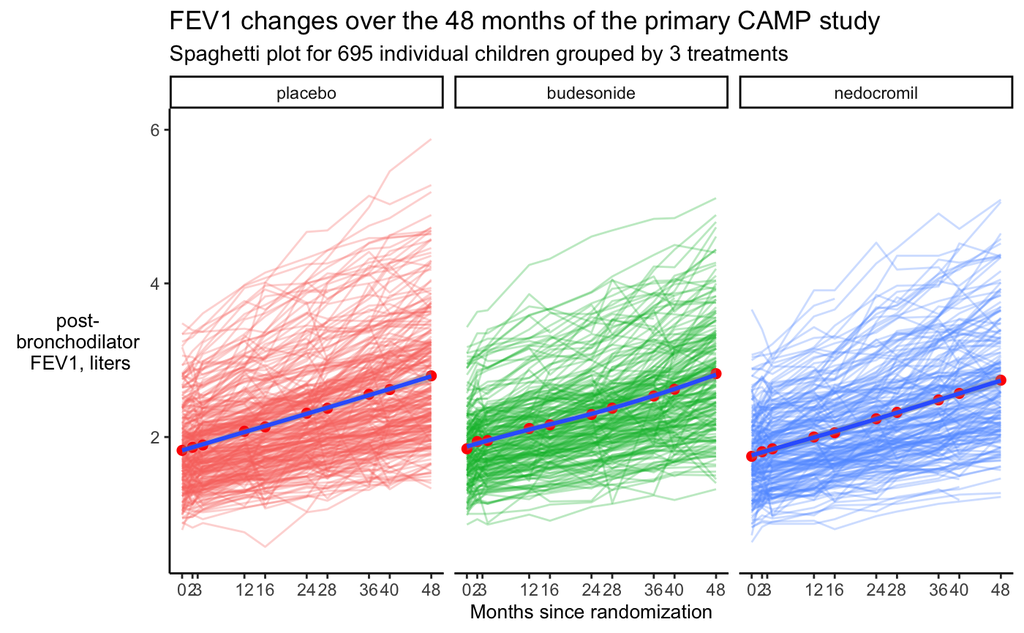

```r
camp_primary %>%
 ggplot() +
  geom_line(aes(group = id, x = visitc, y = POSFEV,
                color = trt),
            alpha = 0.3) +
  scale_x_continuous(breaks = c(0, 2, 3, 12, 16, 24, 28, 36, 40, 48)) +
  ylim(0.5, 6) +
  theme_classic() +
  xlab("Months since randomization") +
  ylab("post-\n bronchodilator \n FEV1, liters") +
  ggtitle("FEV1 changes over the 48 months of the primary CAMP study") +
  labs(subtitle = "Spaghetti plot for 695 individual children grouped by 3 treatments") +
  theme(axis.title.y = element_text(angle = 0, vjust = 0.5, size = 10),
        axis.title.x = element_text(size = 10)) +
  stat_summary(fun.y = mean, geom = "point", lwd = 2, colour = "red",
               aes(x = visitc, y = POSFEV)) + ## add children average per visit
  stat_smooth(aes(group = 1, x = visitc, y = POSFEV)) + ## add children mean lowess line
  facet_wrap("trt", strip.position = "top") +
  theme(legend.position='none')
```

## Part 1.2e

5. Based on your exploratory analysis above, propose a model for the mean FEV1 as a function of time which would allow you to compare whether the changes in the mean FEV1 over time differ across treatment group. Using the regression coefficients from your proposed model, specify the null and alternative hypothesis for testing whether the mean changes over time in FEV1 differ across treatment group

Marginal model for the mean FEV1

$$E(Y_{ij}|X_{ij}) = \beta_0 + \beta_1visitc_{ij} + \beta_2I(trt_i=budesonide) +
\beta_3I(trt_i=nedocromil) + \\
\beta_4visitc_{ij}*I(trt_i=budesonide) +
\beta_5visitc_{ij}*I(trt_i=nedocromil); \\
i = 1,2,3,...,695; j=1,2,3,...,10$$

null and alternative hypothesis

$$H_0: \beta_4=\beta_5=0 \\
H_a: \beta_4=\beta_5 \ne 0$$

## Part 1.2f

Often in randomized controlled trials with longitudinal designs (similar to the CAMP), researchers are not willing to assume a priori that the mean of the primary outcome will change over time according to a parametric model (e.g. linear, quadratic, etc.). Instead researchers fit a model that allows the mean of the primary outcome to be estimated separately at each assessment time; i.e. allowing time to be a factor, not a continuous exposure. Write out a model for the mean FEV1 as a function of time which treats time as a factor (i.e. estimates a separate mean FEV1 at each assessment time) and allows these means to vary across treatment group. Using the regression coefficients from your model, specify the null and alternative hypothesis for testing whether the mean changes over time in FEV1 differ across treatment group.

Model:

- a model for the mean FEV1 as a function of time which treats time as a factor

$trt_{ij}$: treatment groups: placebo; budesonide; nedocromil

$visitc_{ij}$: months since randomization: 0, 2, 4, 12, 16, 24, 28, 36, 40, 48

Propose a model:

$$E(Y_{ij}|X_{ij}) = \beta_0 + \beta_1I(visitc_{ij}=2 months) + \beta_2I(visitc_{ij}=4 months) +...+\beta_9I(visitc_{ij}=48 months) + \\
\beta_{10}I(trt_i=budesonide) + \beta_{11}I(trt_i=nedocromil) + \\
\beta_{12}I(visitc_{ij}=2 months)*I(trt_i=budesonide) +...+\beta_{20}I(visitc_{ij}=48 months)*I(trt_i=budesonide) +\\
\beta_{21}I(visitc_{ij}=2 months)*I(trt_i=nedocromil) +...+\beta_{29}I(visitc_{ij}=48 months)*I(trt_i=nedocromil) ;\\
i= 1, 2,..., 695; j=1,2,3,...,10$$

null and alternative hypothesis:

$$H_0: \beta_{12}=\beta_{13}=...=\beta_{29}=0 \\
H_a: \beta_{12}=\beta_{13}=...=\beta_{29}\ne 0$$

# Part 2. Exploratory Data Analysis of the Variance/Covariance

## 2.1 get residuals

Create a set of residuals to allow exploration of the variance and covariance in the CAMP data. Specifically, use a standard regression model (assuming independence of observations) to fit the mean model you proposed in Part I Section f. Use the fit of the model to compute and save the residuals.

```r
mod1 <- lm(data = camp_primary, POSFEV ~ factor(visitc)*trt)
camp_primary$resid1 <- residuals(mod1)
head(camp_primary, 10)
```

| id | age_rz | POSFEV | visitc | fdays | gender | ethnic | trt | visit | nobs | resid1 |
| --- | --- | --- | --- | --- | --- | --- | --- | --- | --- | --- |
| 1 | 5 | 1.54 | 0 | 0 | male | Other | nedocromil | 1 | 10 | -0.209 |
| 1 | 5 | 1.41 | 2 | 68 | male | Other | nedocromil | 2 | 10 | -0.398 |
| 1 | 5 | 1.56 | 4 | 175 | male | Other | nedocromil | 3 | 10 | -0.286 |
| 1 | 5 | 1.60 | 12 | 370 | male | Other | nedocromil | 4 | 10 | -0.400 |
| 1 | 5 | 1.73 | 16 | 455 | male | Other | nedocromil | 5 | 10 | -0.326 |
| 1 | 5 | 1.82 | 24 | 734 | male | Other | nedocromil | 6 | 10 | -0.418 |
| 1 | 5 | 2.07 | 28 | 868 | male | Other | nedocromil | 7 | 10 | -0.251 |
| 1 | 5 | 2.20 | 36 | 1133 | male | Other | nedocromil | 8 | 10 | -0.283 |
| 1 | 5 | 2.20 | 40 | 1232 | male | Other | nedocromil | 9 | 10 | -0.368 |
| 1 | 5 | 2.39 | 48 | 1462 | male | Other | nedocromil | 10 | 10 | -0.350 |

## 2.2 Variance matrix

2. Use a graphical display and relevant summary statistics to explore the assumption of constant variance over time, overall and then separately within each treatment group.

```r
# Reshape the data to wide format
camp.wide <-
  camp_primary %>%
  select(id, visitc, trt, resid1) %>%
  pivot_wider(names_from = "visitc", ## the column name you want
              names_prefix = "month", ## modifies your new column names
              values_from = "resid1") ## the value col in the long data
head(camp.wide, 10)
```

| id | trt | month0 | month2 | month4 | month12 | month16 | month24 | month28 | month36 | month40 | month48 |
| --- | --- | --- | --- | --- | --- | --- | --- | --- | --- | --- | --- |
| 1 | nedocromil | -0.209 | -0.398 | -0.286 | -0.400 | -0.326 | -0.418 | -0.251 | -0.283 | -0.368 | -0.349724 |
| 2 | nedocromil | 0.361 | 0.152 | 0.134 | 0.380 | 0.134 | 0.402 | 0.679 | 0.257 | 0.692 | -0.169724 |
| 4 | nedocromil | 0.661 | 0.652 | 0.814 | 0.770 | 0.704 | 0.872 | 1.039 | 0.787 | 0.752 | NA |
| 5 | nedocromil | -0.609 | -0.628 | -0.596 | -0.780 | -0.776 | -1.048 | -0.861 | -0.893 | -1.068 | -1.129724 |
| 6 | nedocromil | -0.279 | -0.438 | -0.446 | -0.480 | -0.396 | -0.388 | NA | -0.213 | NA | 0.000276 |
| 9 | budesonide | -0.167 | NA | -0.225 | -0.311 | -0.268 | -0.363 | -0.445 | -0.453 | -0.521 | -0.574715 |
| 10 | placebo | 0.844 | 0.864 | 1.084 | 1.265 | 1.438 | 1.610 | 1.755 | 1.544 | 1.643 | 1.663532 |
| 12 | placebo | -0.506 | -0.496 | -0.636 | -0.515 | -0.402 | -0.650 | -0.595 | -0.706 | -0.907 | -0.916468 |
| 13 | placebo | -0.156 | -0.136 | -0.106 | -0.225 | -0.262 | -0.350 | -0.385 | -0.506 | -0.477 | -0.656468 |
| 14 | nedocromil | -0.409 | -0.508 | -0.546 | -0.700 | -0.676 | -0.608 | -0.701 | -0.653 | -0.698 | -0.639724 |

### Variance matrix - all

```r
options(digits = 3)
camp.wide %>%
  select(!c(id,trt)) %>%
  cov(use = "na.or.complete")
```

```
        month0 month2 month4 month12 month16 month24 month28 month36 month40 month48
month0   0.249  0.238  0.241   0.268   0.271   0.295   0.304   0.323   0.329   0.342
month2   0.238  0.245  0.241   0.267   0.272   0.296   0.303   0.322   0.328   0.340
month4   0.241  0.241  0.254   0.272   0.279   0.300   0.310   0.329   0.335   0.349
month12  0.268  0.267  0.272   0.316   0.315   0.342   0.353   0.372   0.377   0.388
month16  0.271  0.272  0.279   0.315   0.340   0.356   0.367   0.390   0.393   0.403
month24  0.295  0.296  0.300   0.342   0.356   0.407   0.411   0.437   0.441   0.456
month28  0.304  0.303  0.310   0.353   0.367   0.411   0.440   0.456   0.463   0.478
month36  0.323  0.322  0.329   0.372   0.390   0.437   0.456   0.512   0.510   0.534
month40  0.329  0.328  0.335   0.377   0.393   0.441   0.463   0.510   0.538   0.556
month48  0.342  0.340  0.349   0.388   0.403   0.456   0.478   0.534   0.556   0.617
```

### Variance matrix - placobe

```r
options(digits = 3)
camp.wide %>%
  filter(trt == "placebo") %>%
  select(!c(id,trt)) %>%
  cov(use = "na.or.complete")
```

```
        month0 month2 month4 month12 month16 month24 month28 month36 month40 month48
month0   0.266  0.259  0.261   0.287   0.301   0.325   0.334   0.366   0.376   0.388
month2   0.259  0.267  0.262   0.290   0.305   0.332   0.338   0.369   0.381   0.389
month4   0.261  0.262  0.274   0.293   0.313   0.337   0.346   0.376   0.389   0.401
month12  0.287  0.290  0.293   0.339   0.349   0.380   0.387   0.423   0.432   0.440
month16  0.301  0.305  0.313   0.349   0.392   0.407   0.417   0.458   0.465   0.472
month24  0.325  0.332  0.337   0.380   0.407   0.457   0.462   0.501   0.512   0.521
month28  0.334  0.338  0.346   0.387   0.417   0.462   0.488   0.523   0.539   0.550
month36  0.366  0.369  0.376   0.423   0.458   0.501   0.523   0.596   0.603   0.624
month40  0.376  0.381  0.389   0.432   0.465   0.512   0.539   0.603   0.635   0.653
month48  0.388  0.389  0.401   0.440   0.472   0.521   0.550   0.624   0.653   0.709
```

### Variance matrix - budesonide

```r
options(digits = 3)
camp.wide %>%
  filter(trt == "budesonide") %>%
  select(!c(id,trt)) %>%
  cov(use = "na.or.complete")
```

```
        month0 month2 month4 month12 month16 month24 month28 month36 month40 month48
month0   0.227  0.223  0.228   0.253   0.251   0.258   0.271   0.277   0.280   0.303
month2   0.223  0.234  0.233   0.257   0.257   0.265   0.274   0.282   0.282   0.306
month4   0.228  0.233  0.247   0.264   0.261   0.269   0.281   0.287   0.286   0.310
month12  0.253  0.257  0.264   0.306   0.298   0.304   0.321   0.323   0.325   0.347
month16  0.251  0.257  0.261   0.298   0.310   0.311   0.327   0.332   0.330   0.350
month24  0.258  0.265  0.269   0.304   0.311   0.337   0.346   0.358   0.358   0.387
month28  0.271  0.274  0.281   0.321   0.327   0.346   0.389   0.381   0.380   0.409
month36  0.277  0.282  0.287   0.323   0.332   0.358   0.381   0.419   0.405   0.442
month40  0.280  0.282  0.286   0.325   0.330   0.358   0.380   0.405   0.430   0.455
month48  0.303  0.306  0.310   0.347   0.350   0.387   0.409   0.442   0.455   0.535
```

### Variance matrix - nedocromil

```r
options(digits = 3)
camp.wide %>%
  filter(trt == "nedocromil") %>%
  select(!c(id,trt)) %>%
  cov(use = "na.or.complete")
```

```
        month0 month2 month4 month12 month16 month24 month28 month36 month40 month48
month0   0.253  0.230  0.231   0.261   0.257   0.297   0.304   0.319   0.322   0.326
month2   0.230  0.232  0.225   0.251   0.247   0.284   0.290   0.307   0.310   0.316
month4   0.231  0.225  0.238   0.256   0.255   0.286   0.297   0.315   0.320   0.327
month12  0.261  0.251  0.256   0.300   0.293   0.336   0.345   0.359   0.363   0.367
month16  0.257  0.247  0.255   0.293   0.306   0.341   0.348   0.366   0.368   0.373
month24  0.297  0.284  0.286   0.336   0.341   0.419   0.417   0.440   0.442   0.447
month28  0.304  0.290  0.297   0.345   0.348   0.417   0.434   0.450   0.457   0.462
month36  0.319  0.307  0.315   0.359   0.366   0.440   0.450   0.504   0.504   0.519
month40  0.322  0.310  0.320   0.363   0.368   0.442   0.457   0.504   0.531   0.540
month48  0.326  0.316  0.327   0.367   0.373   0.447   0.462   0.519   0.540   0.592
```

### Residuals scatter plot

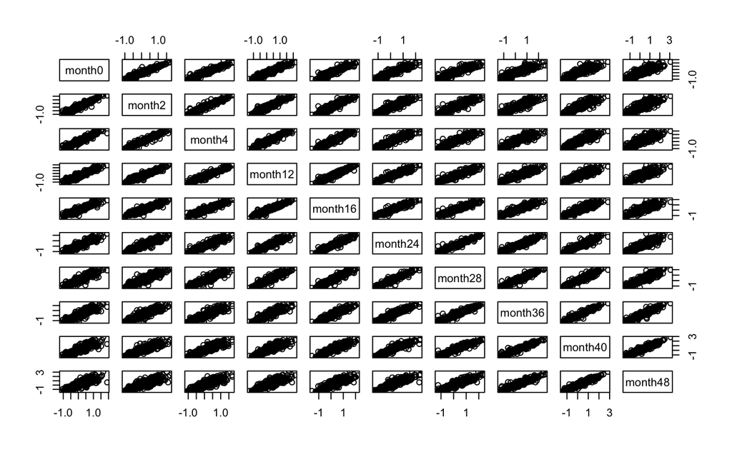

```r
camp.wide %>%
  select(!c(id,trt)) %>%
  pairs
```

## 2.3.a empirical correlation matrix

1. Convert your dataset to a wide format and create the empirical correlation matrix based on the residuals you have calculated.

```r
options(digits = 3)
    # print fewer digits makes it easier to look at
    # the correlation matix
camp.wide %>%
  select(!c(id,trt)) %>%
  cor(use = "na.or.complete")
```

```
        month0 month2 month4 month12 month16 month24 month28 month36 month40 month48
month0   1.000  0.964  0.958   0.955   0.933   0.928   0.919   0.905   0.898   0.871
month2   0.964  1.000  0.966   0.960   0.942   0.936   0.922   0.910   0.902   0.875
month4   0.958  0.966  1.000   0.960   0.948   0.932   0.928   0.913   0.906   0.881
month12  0.955  0.960  0.960   1.000   0.963   0.954   0.946   0.924   0.913   0.878
month16  0.933  0.942  0.948   0.963   1.000   0.958   0.950   0.936   0.918   0.880
month24  0.928  0.936  0.932   0.954   0.958   1.000   0.972   0.958   0.943   0.909
month28  0.919  0.922  0.928   0.946   0.950   0.972   1.000   0.961   0.952   0.918
month36  0.905  0.910  0.913   0.924   0.936   0.958   0.961   1.000   0.972   0.950
month40  0.898  0.902  0.906   0.913   0.918   0.943   0.952   0.972   1.000   0.964
month48  0.871  0.875  0.881   0.878   0.880   0.909   0.918   0.950   0.964   1.000
```

## 2.3.b autocor and variogram

2. Using the “visitc” variable to measure time, create a variogram to explore the autocorrelation function (see Lecture 3 do-file for assistance). NOTE: You could also use the “fdays” variable which measures time from randomization in days. Describe the pattern you observe in the autocorrelation function.

### autocorrelation function

```r
## Fit Linear Model Using Generalized Least Squares
library(nlme)
fit_vario <- gls(POSFEV ~ visitc + trt:visitc, data = camp_primary)
est_acf <- ACF(fit_vario, form=~1|id)
est_acf
```

|  | lag | ACF |
| --- | --- | --- |
| 1 | 0 | 1.000 |
| 2 | 1 | 0.950 |
| 3 | 2 | 0.932 |
| 4 | 3 | 0.908 |
| 5 | 4 | 0.885 |
| 6 | 5 | 0.863 |
| 7 | 6 | 0.852 |
| 8 | 7 | 0.841 |
| 9 | 8 | 0.847 |
| 10 | 9 | 0.844 |

### Variogram

```r
## specify resType="response" to obtain the estimated variogram as defined in class
est_vario <- Variogram(fit_vario, form = ~visitc|id, resType="response")
sig2_hat <- var(resid(fit_vario))
```

```r
## set some defaults for plotting
textsize <- 1.5  ## plotting text size
chrsize  <- 1  ## plotting character (point size) parameter
linesize <- 2   ## plotting line width parameter
```

```r
## plot variogram
par(mfrow=c(1,2),las=1)

scatter.smooth(est_vario$dist, est_vario$variog, ylim=c(0,0.5),
               ylab="",xlab="Distance (months)", main=expression("Variogram: " ~ hat(gamma)(u[jk])),
               pch=16, cex.main=textsize, cex.lab=textsize, cex.axis=chrsize, cex=1,
               lwd=linesize, lpars=list(col='red',lty=1,lwd=linesize),xlim=c(0,50))

abline(h=sig2_hat, lty=2, col='grey',lwd=2)
```

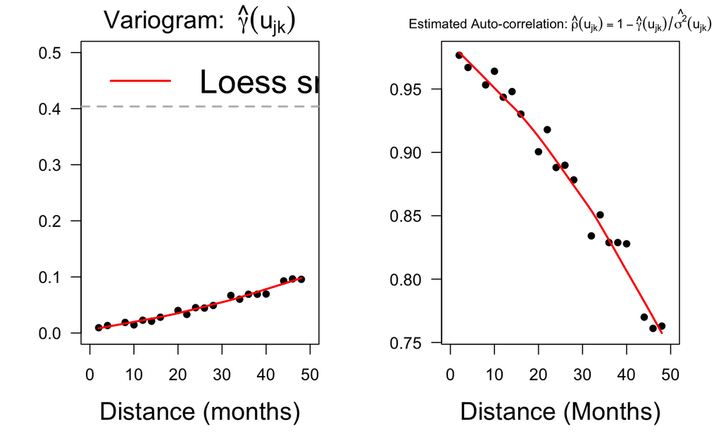

```r
legend("topleft","Loess smooth", col="red", lty=1,lwd=2,bty='n',cex=linesize)

scatter.smooth(est_vario$dist, 1-est_vario$variog/sig2_hat, pch=16,ylab="",xlab="Distance (Months)",
               main=expression("Estimated Auto-correlation:" ~ hat(rho)(u[jk]) == 1-hat(gamma)(u[jk])/hat(sigma^2)(u[jk])),
               cex.main=0.8, cex.lab=textsize, cex.axis=chrsize, cex=linesize/2,
               lpars=list(col='red',lty=1,lwd=linesize),xlim=c(0,50))
```

```r
NA
NA
```

## 2.4

4. Based on your findings, propose a parametric model for the within subject correlation structure.

unstructured?

# Part 3. Marginal Model Implementation

## 3.1

Fit the proposed model from PART 1.2.e with the parametric correlation model proposed in PART 2.

For each of the models, calculate the AIC.

```r
## Fit the model using ML: unstructured variance/covariance
mod3.1 <- gls(data = camp_primary,
              POSFEV ~ as.factor(visitc)+ trt + as.factor(visitc):trt,
              correlation = corSymm(form = ~ visit | id),
              weights = varIdent(form = ~ 1 | visit))
```

[output not shown]

## 3.2 - exchangeable

Refit the mean model assuming the independence and exchangeable correlation working models.

Compute the AIC for each of these two approaches.

```r
## exchangeable correlation working models
library(doBy)
mod3.2 <- gls(data = camp_primary,
              POSFEV ~ as.factor(visitc)+ trt + as.factor(visitc):trt, ## as.factor(visitc)*trt
              correlation = corCompSymm(form = ~ visitc | id))
summary(mod3.2)
```

```
Generalized least squares fit by REML
  Model: POSFEV ~ as.factor(visitc) + trt + as.factor(visitc):trt
  Data: camp_primary
```

|  | AIC | BIC | logLik |
| --- | --- | --- | --- |
|  | 579 | 796 | -258 |

```
Correlation Structure: Compound symmetry
 Formula: ~visitc | id
 Parameter estimate(s):
  Rho
0.905

Coefficients:
```

|  | Value | Std.Error | t-value | p-value |
| --- | --- | --- | --- | --- |
| (Intercept) | 1.823 | 0.0384 | 47.4 | 0.0000 |
| as.factor(visitc)2 | 0.043 | 0.0171 | 2.5 | 0.0114 |
| as.factor(visitc)4 | 0.089 | 0.0170 | 5.2 | 0.0000 |
| as.factor(visitc)12 | 0.258 | 0.0169 | 15.2 | 0.0000 |
| as.factor(visitc)16 | 0.320 | 0.0170 | 18.8 | 0.0000 |
| as.factor(visitc)24 | 0.492 | 0.0171 | 28.8 | 0.0000 |
| as.factor(visitc)28 | 0.567 | 0.0172 | 32.9 | 0.0000 |
| as.factor(visitc)36 | 0.756 | 0.0171 | 44.2 | 0.0000 |
| as.factor(visitc)40 | 0.827 | 0.0173 | 47.9 | 0.0000 |
| as.factor(visitc)48 | 0.993 | 0.0172 | 57.7 | 0.0000 |

[output cut: 20 more lines]

```
 Correlation:
                                  (Intr) as.()2 as.()4 as.()12 as.()16 as.()24 as.()28 as.()36
as.factor(visitc)2                -0.214
as.factor(visitc)4                -0.215  0.484
as.factor(visitc)12               -0.216  0.488  0.490
as.factor(visitc)16               -0.214  0.485  0.487  0.492
as.factor(visitc)24               -0.214  0.484  0.485  0.490   0.488
as.factor(visitc)28               -0.212  0.481  0.482  0.487   0.485   0.485
as.factor(visitc)36               -0.213  0.483  0.484  0.489   0.486   0.487   0.484
as.factor(visitc)40               -0.212  0.479  0.480  0.485   0.482   0.483   0.480   0.483
as.factor(visitc)48               -0.212  0.481  0.482  0.486   0.484   0.484   0.481   0.484
trtbudesonide                     -0.658  0.141  0.141  0.142   0.141   0.141   0.140   0.140
trtnedocromil                     -0.658  0.141  0.141  0.142   0.141   0.141   0.140   0.140
as.factor(visitc)2:trtbudesonide   0.141 -0.659 -0.319 -0.322  -0.320  -0.319  -0.317  -0.318
as.factor(visitc)4:trtbudesonide   0.142 -0.319 -0.659 -0.322  -0.321  -0.319  -0.317  -0.319
as.factor(visitc)12:trtbudesonide  0.142 -0.321 -0.322 -0.657  -0.323  -0.322  -0.320  -0.321
as.factor(visitc)16:trtbudesonide  0.141 -0.320 -0.321 -0.324  -0.659  -0.322  -0.320  -0.321
as.factor(visitc)24:trtbudesonide  0.141 -0.320 -0.321 -0.324  -0.323  -0.661  -0.321  -0.322
as.factor(visitc)28:trtbudesonide  0.140 -0.317 -0.318 -0.321  -0.320  -0.320  -0.660  -0.319
as.factor(visitc)36:trtbudesonide  0.141 -0.318 -0.320 -0.322  -0.321  -0.321  -0.319  -0.660
as.factor(visitc)40:trtbudesonide  0.140 -0.315 -0.316 -0.319  -0.318  -0.318  -0.316  -0.318
as.factor(visitc)48:trtbudesonide  0.140 -0.317 -0.317 -0.320  -0.318  -0.319  -0.317  -0.318
as.factor(visitc)2:trtnedocromil   0.142 -0.663 -0.321 -0.323  -0.321  -0.320  -0.319  -0.320
as.factor(visitc)4:trtnedocromil   0.142 -0.321 -0.662 -0.324  -0.322  -0.321  -0.319  -0.321
as.factor(visitc)12:trtnedocromil  0.143 -0.322 -0.324 -0.661  -0.325  -0.324  -0.322  -0.323
as.factor(visitc)16:trtnedocromil  0.142 -0.320 -0.322 -0.325  -0.661  -0.323  -0.320  -0.321
as.factor(visitc)24:trtnedocromil  0.141 -0.319 -0.320 -0.324  -0.322  -0.660  -0.320  -0.321
as.factor(visitc)28:trtnedocromil  0.140 -0.317 -0.318 -0.321  -0.320  -0.320  -0.659  -0.319
as.factor(visitc)36:trtnedocromil  0.141 -0.318 -0.319 -0.322  -0.320  -0.321  -0.319  -0.659
as.factor(visitc)40:trtnedocromil  0.139 -0.315 -0.316 -0.318  -0.317  -0.317  -0.315  -0.317
as.factor(visitc)48:trtnedocromil  0.138 -0.314 -0.314 -0.317  -0.315  -0.316  -0.313  -0.315
                                  as.()40 as.()48 trtbds trtndc as.fctr(vstc)2:trtb
as.factor(visitc)2
as.factor(visitc)4
as.factor(visitc)12
as.factor(visitc)16
as.factor(visitc)24
as.factor(visitc)28
as.factor(visitc)36
as.factor(visitc)40
```

[output cut: 193 more lines]

```
as.factor(visitc)4:trtnedocromil
as.factor(visitc)12:trtnedocromil
as.factor(visitc)16:trtnedocromil
as.factor(visitc)24:trtnedocromil
as.factor(visitc)28:trtnedocromil
as.factor(visitc)36:trtnedocromil
as.factor(visitc)40:trtnedocromil
as.factor(visitc)48:trtnedocromil  0.474

Standardized residuals:
   Min     Q1    Med     Q3    Max
-2.469 -0.725 -0.154  0.511  4.812

Residual standard error: 0.637
Degrees of freedom: 6569 total; 6539 residual
```

```r
# esticon(mod3.2, L = m, level = 0.95, beta0 = c(0,0,0), joint.test = T)

## L, define matrix for our linear contrasts?
```

## 3.2 - independence

```r
## independence
mod3.2.2 <- gls(data = camp_primary,
              POSFEV ~ as.factor(visitc)+ trt + as.factor(visitc):trt,
              correlation = NULL)
summary(mod3.2.2)
```

```
Generalized least squares fit by REML
  Model: POSFEV ~ as.factor(visitc) + trt + as.factor(visitc):trt
  Data: camp_primary
```

|  | AIC | BIC | logLik |
| --- | --- | --- | --- |
|  | 12865 | 13075 | -6401 |

```
Coefficients:
```

|  | Value | Std.Error | t-value | p-value |
| --- | --- | --- | --- | --- |
| (Intercept) | 1.826 | 0.0384 | 47.5 | 0.000 |
| as.factor(visitc)2 | 0.040 | 0.0552 | 0.7 | 0.470 |
| as.factor(visitc)4 | 0.070 | 0.0550 | 1.3 | 0.206 |
| as.factor(visitc)12 | 0.249 | 0.0548 | 4.5 | 0.000 |
| as.factor(visitc)16 | 0.306 | 0.0551 | 5.6 | 0.000 |
| as.factor(visitc)24 | 0.484 | 0.0552 | 8.8 | 0.000 |
| as.factor(visitc)28 | 0.548 | 0.0556 | 9.9 | 0.000 |
| as.factor(visitc)36 | 0.730 | 0.0553 | 13.2 | 0.000 |
| as.factor(visitc)40 | 0.791 | 0.0557 | 14.2 | 0.000 |
| as.factor(visitc)48 | 0.970 | 0.0555 | 17.5 | 0.000 |

[output cut: 20 more lines]

```
 Correlation:
                                  (Intr) as.()2 as.()4 as.()12 as.()16 as.()24 as.()28 as.()36
as.factor(visitc)2                -0.696
as.factor(visitc)4                -0.698  0.486
as.factor(visitc)12               -0.701  0.488  0.490
as.factor(visitc)16               -0.698  0.486  0.487  0.489
as.factor(visitc)24               -0.696  0.485  0.486  0.488   0.486
as.factor(visitc)28               -0.691  0.482  0.483  0.485   0.482   0.482
as.factor(visitc)36               -0.695  0.484  0.485  0.487   0.485   0.484   0.481
as.factor(visitc)40               -0.690  0.481  0.482  0.484   0.481   0.481   0.477   0.480
as.factor(visitc)48               -0.692  0.482  0.483  0.485   0.483   0.482   0.479   0.481
trtbudesonide                     -0.659  0.459  0.460  0.462   0.460   0.459   0.455   0.458
trtnedocromil                     -0.659  0.459  0.460  0.462   0.460   0.459   0.455   0.458
as.factor(visitc)2:trtbudesonide   0.459 -0.660 -0.321 -0.322  -0.321  -0.320  -0.318  -0.319
as.factor(visitc)4:trtbudesonide   0.460 -0.321 -0.659 -0.323  -0.321  -0.321  -0.318  -0.320
as.factor(visitc)12:trtbudesonide  0.461 -0.321 -0.322 -0.658  -0.322  -0.321  -0.319  -0.321
as.factor(visitc)16:trtbudesonide  0.460 -0.320 -0.321 -0.323  -0.660  -0.320  -0.318  -0.320
as.factor(visitc)24:trtbudesonide  0.460 -0.321 -0.322 -0.323  -0.321  -0.661  -0.318  -0.320
as.factor(visitc)28:trtbudesonide  0.456 -0.318 -0.319 -0.320  -0.318  -0.318  -0.660  -0.317
as.factor(visitc)36:trtbudesonide  0.459 -0.319 -0.320 -0.322  -0.320  -0.319  -0.317  -0.660
as.factor(visitc)40:trtbudesonide  0.455 -0.317 -0.318 -0.319  -0.317  -0.317  -0.315  -0.316
as.factor(visitc)48:trtbudesonide  0.456 -0.317 -0.318 -0.320  -0.318  -0.317  -0.315  -0.317
as.factor(visitc)2:trtnedocromil   0.461 -0.662 -0.322 -0.323  -0.322  -0.321  -0.319  -0.320
as.factor(visitc)4:trtnedocromil   0.462 -0.322 -0.662 -0.324  -0.323  -0.322  -0.320  -0.321
as.factor(visitc)12:trtnedocromil  0.463 -0.323 -0.323 -0.660  -0.323  -0.323  -0.320  -0.322
as.factor(visitc)16:trtnedocromil  0.461 -0.321 -0.322 -0.323  -0.660  -0.321  -0.319  -0.320
as.factor(visitc)24:trtnedocromil  0.459 -0.320 -0.321 -0.322  -0.321  -0.660  -0.318  -0.319
as.factor(visitc)28:trtnedocromil  0.456 -0.317 -0.318 -0.320  -0.318  -0.317  -0.659  -0.317
as.factor(visitc)36:trtnedocromil  0.458 -0.319 -0.320 -0.321  -0.319  -0.319  -0.316  -0.659
as.factor(visitc)40:trtnedocromil  0.453 -0.316 -0.317 -0.318  -0.316  -0.316  -0.314  -0.315
as.factor(visitc)48:trtnedocromil  0.451 -0.314 -0.315 -0.317  -0.315  -0.314  -0.312  -0.314
                                  as.()40 as.()48 trtbds trtndc as.fctr(vstc)2:trtb
as.factor(visitc)2
as.factor(visitc)4
as.factor(visitc)12
as.factor(visitc)16
as.factor(visitc)24
as.factor(visitc)28
as.factor(visitc)36
as.factor(visitc)40
```

[output cut: 193 more lines]

```
as.factor(visitc)4:trtnedocromil
as.factor(visitc)12:trtnedocromil
as.factor(visitc)16:trtnedocromil
as.factor(visitc)24:trtnedocromil
as.factor(visitc)28:trtnedocromil
as.factor(visitc)36:trtnedocromil
as.factor(visitc)40:trtnedocromil
as.factor(visitc)48:trtnedocromil  0.472

Standardized residuals:
   Min     Q1    Med     Q3    Max
-2.455 -0.716 -0.147  0.523  4.847

Residual standard error: 0.636
Degrees of freedom: 6569 total; 6539 residual
```

## 3.3 - AR(1) + random intercept model

```r
mod3.3 <- lme(data = camp_primary,
              POSFEV ~ as.factor(visitc)+ trt + as.factor(visitc):trt,
              random = ~1|id, na.action=na.omit,
              correlation = corExp(form = ~visitc|id))
summary(mod3.3)
```

```
Linear mixed-effects model fit by REML
 Data: camp_primary
```

|  | AIC | BIC | logLik |
| --- | --- | --- | --- |
|  | -2433 | -2209 | 1250 |

```
Random effects:
 Formula: ~1 | id
        (Intercept) Residual
StdDev:       0.595     0.28

Correlation Structure: Exponential spatial correlation
 Formula: ~visitc | id
 Parameter estimate(s):
range
 21.3
Fixed effects: POSFEV ~ as.factor(visitc) + trt + as.factor(visitc):trt
```

|  | Value | Std.Error | DF | t-value | p-value |
| --- | --- | --- | --- | --- | --- |
| (Intercept) | 1.824 | 0.0397 | 5847 | 46.0 | 0.0000 |
| as.factor(visitc)2 | 0.045 | 0.0073 | 5847 | 6.1 | 0.0000 |
| as.factor(visitc)4 | 0.084 | 0.0100 | 5847 | 8.4 | 0.0000 |
| as.factor(visitc)12 | 0.257 | 0.0159 | 5847 | 16.2 | 0.0000 |
| as.factor(visitc)16 | 0.317 | 0.0176 | 5847 | 18.0 | 0.0000 |
| as.factor(visitc)24 | 0.488 | 0.0200 | 5847 | 24.4 | 0.0000 |
| as.factor(visitc)28 | 0.563 | 0.0209 | 5847 | 27.0 | 0.0000 |
| as.factor(visitc)36 | 0.755 | 0.0220 | 5847 | 34.3 | 0.0000 |
| as.factor(visitc)40 | 0.826 | 0.0225 | 5847 | 36.8 | 0.0000 |
| as.factor(visitc)48 | 0.985 | 0.0232 | 5847 | 42.5 | 0.0000 |

[output cut: 20 more lines]

```
 Correlation:
                                  (Intr) as.()2 as.()4 as.()12 as.()16 as.()24 as.()28 as.()36
as.factor(visitc)2                -0.089
as.factor(visitc)4                -0.124  0.675
as.factor(visitc)12               -0.196  0.361  0.523
as.factor(visitc)16               -0.216  0.304  0.438  0.822
as.factor(visitc)24               -0.244  0.239  0.342  0.619   0.737
as.factor(visitc)28               -0.253  0.219  0.312  0.556   0.657   0.873
as.factor(visitc)36               -0.267  0.193  0.273  0.473   0.550   0.706   0.790
as.factor(visitc)40               -0.271  0.183  0.259  0.443   0.512   0.647   0.718   0.891
as.factor(visitc)48               -0.278  0.170  0.239  0.401   0.458   0.564   0.616   0.739
trtbudesonide                     -0.658  0.059  0.081  0.129   0.142   0.160   0.166   0.176
trtnedocromil                     -0.658  0.059  0.081  0.129   0.142   0.160   0.166   0.176
as.factor(visitc)2:trtbudesonide   0.059 -0.659 -0.445 -0.238  -0.200  -0.157  -0.144  -0.127
as.factor(visitc)4:trtbudesonide   0.081 -0.444 -0.659 -0.344  -0.288  -0.225  -0.205  -0.180
as.factor(visitc)12:trtbudesonide  0.129 -0.238 -0.344 -0.658  -0.541  -0.407  -0.366  -0.311
as.factor(visitc)16:trtbudesonide  0.142 -0.200 -0.289 -0.542  -0.659  -0.486  -0.433  -0.363
as.factor(visitc)24:trtbudesonide  0.161 -0.158 -0.226 -0.409  -0.487  -0.660  -0.577  -0.466
as.factor(visitc)28:trtbudesonide  0.167 -0.144 -0.206 -0.367  -0.433  -0.576  -0.660  -0.521
as.factor(visitc)36:trtbudesonide  0.176 -0.127 -0.180 -0.312  -0.363  -0.466  -0.521  -0.660
as.factor(visitc)40:trtbudesonide  0.179 -0.121 -0.171 -0.292  -0.338  -0.427  -0.474  -0.588
as.factor(visitc)48:trtbudesonide  0.183 -0.112 -0.157 -0.264  -0.302  -0.371  -0.406  -0.487
as.factor(visitc)2:trtnedocromil   0.059 -0.663 -0.447 -0.239  -0.201  -0.158  -0.145  -0.128
as.factor(visitc)4:trtnedocromil   0.082 -0.447 -0.662 -0.346  -0.290  -0.226  -0.206  -0.181
as.factor(visitc)12:trtnedocromil  0.129 -0.239 -0.345 -0.661  -0.544  -0.409  -0.368  -0.313
as.factor(visitc)16:trtnedocromil  0.143 -0.201 -0.289 -0.543  -0.661  -0.488  -0.434  -0.364
as.factor(visitc)24:trtnedocromil  0.161 -0.158 -0.226 -0.409  -0.487  -0.660  -0.577  -0.466
as.factor(visitc)28:trtnedocromil  0.167 -0.144 -0.206 -0.367  -0.433  -0.576  -0.660  -0.521
as.factor(visitc)36:trtnedocromil  0.176 -0.127 -0.180 -0.312  -0.362  -0.465  -0.521  -0.659
as.factor(visitc)40:trtnedocromil  0.179 -0.120 -0.170 -0.291  -0.337  -0.426  -0.472  -0.586
as.factor(visitc)48:trtnedocromil  0.182 -0.111 -0.156 -0.262  -0.299  -0.369  -0.403  -0.483
                                  as.()40 as.()48 trtbds trtndc as.fctr(vstc)2:trtb
as.factor(visitc)2
as.factor(visitc)4
as.factor(visitc)12
as.factor(visitc)16
as.factor(visitc)24
as.factor(visitc)28
as.factor(visitc)36
as.factor(visitc)40
```

[output cut: 193 more lines]

```
as.factor(visitc)4:trtnedocromil
as.factor(visitc)12:trtnedocromil
as.factor(visitc)16:trtnedocromil
as.factor(visitc)24:trtnedocromil
as.factor(visitc)28:trtnedocromil
as.factor(visitc)36:trtnedocromil
as.factor(visitc)40:trtnedocromil
as.factor(visitc)48:trtnedocromil  0.806

Standardized Within-Group Residuals:
    Min      Q1     Med      Q3     Max
-4.0475 -0.4052 -0.0175  0.3686  3.9159

Number of Observations: 6569
Number of Groups: 695
```

## 3.4 test

4. Select the “best fitting” model based on your exploratory analyses and model diagnostics (AIC).

# Part 5. Short Answer

## Question 5.1: Linear mixed effects (random intercept) model

Interpret the coefficients for “visitc” and “1.trt#c.visitc” and provide statistical support for whether there is statistical evidence of a benefit of receiving budesonide compared to placebo for promoting long term improved pulmonary function among children with asthma.

(coefficients interpretation and Wald test for interaction terms)

**Note: exponential spatial correlation model for continuous time variable, AR(1) for discrete time variables**

```r
library(nlme)

fit = lme(POSFEV~visitc+trt:visitc,
          data=camp_primary,
          random=~1|id, na.action=na.omit,
          correlation=corExp(form=~visitc|id))
summary(fit)
```

```
Linear mixed-effects model fit by REML
 Data: camp_primary
```

|  | AIC | BIC | logLik |
| --- | --- | --- | --- |
|  | -2548 | -2500 | 1281 |

```
Random effects:
 Formula: ~1 | id
        (Intercept) Residual
StdDev:       0.596    0.278

Correlation Structure: Exponential spatial correlation
 Formula: ~visitc | id
 Parameter estimate(s):
range
 20.7
Fixed effects: POSFEV ~ visitc + trt:visitc
```

|  | Value | Std.Error | DF | t-value | p-value |
| --- | --- | --- | --- | --- | --- |
| (Intercept) | 1.808 | 0.02476 | 5871 | 73.0 | 0.000 |
| visitc | 0.021 | 0.00047 | 5871 | 44.1 | 0.000 |
| visitc:trtbudesonide | 0.000 | 0.00070 | 5871 | -0.3 | 0.751 |
| visitc:trtnedocromil | 0.000 | 0.00070 | 5871 | -0.5 | 0.648 |

```
 Correlation:
                     (Intr) visitc vstc:trtb
visitc               -0.181
visitc:trtbudesonide  0.000 -0.648
visitc:trtnedocromil -0.001 -0.644  0.432

Standardized Within-Group Residuals:
    Min      Q1     Med      Q3     Max
-4.1216 -0.4118 -0.0172  0.3803  3.9249

Number of Observations: 6569
Number of Groups: 695
```

```r
## Wald test for two interaction terms:

L = cbind(c(0,0,1,0),c(0,0,0,1))

beta = fit$coefficients$fixed

V = fit$varFix

test.stat = t(beta) %*% L %*% solve(t(L) %*% V %*% L) %*% t(L) %*% beta

test.stat
```

```
      [,1]
[1,] 0.226
```

```r
1-pchisq(test.stat,df=2)
```

```
      [,1]
[1,] 0.893
```

$$E(Y_{ij}|X_{ij}) = \beta_0 + \beta_1visitc_{ij} + \beta_2visitc_{ij}*I(trt_i=budesonide) +
\beta_3visitc_{ij}*I(trt_i=nedocromil); \\
i = 1,2,3,...,695; j=1,2,3,...,10$$
$\beta_1$: the difference in mean FEV1 after randomization ($visitc_{i(j+1)}$ vs. $visitc_{ij}$) in the placebo group.

$\beta_2$: the difference between the budesonide treatment and placebo group in the mean FEV1 change after randomization ($visitc_{i(j+1)}$ vs. $visitc_{ij}$).

$\beta_3$: the difference between the nedocromil treatment and placebo group in the mean FEV1 change after randomization ($visitc_{i(j+1)}$ vs. $visitc_{ij}$).

Therefore, there is no statistical evidence of a benefit of receiving budesonide compared to placebo for promoting long term improved pulmonary function among children with asthma.

## Question 5.2 estimate the correlation

Question 2: Using the fit of the model, estimate the correlation between the post-bronchodilator FEV1 at baseline assessment (visitc = 0) and 12-months post randomization (i.e. visitc = 12).

```r
## fit the random intercept + exponential model
fit_pt3_ri_exp <- lme(POSFEV~visitc + trt:visitc, data=camp_primary,
                      random=~1|id, correlation=corExp(form=~visitc|id), method="REML")

## calculate AIC
AIC(fit_pt3_ri_exp)
```

```
[1] -2548
```

```r
## can also find tau2, sigma2, and rho (calculate from range) from the summary output
summary(fit_pt3_ri_exp)
```

```
Linear mixed-effects model fit by REML
 Data: camp_primary
```

|  | AIC | BIC | logLik |
| --- | --- | --- | --- |
|  | -2548 | -2500 | 1281 |

```
Random effects:
 Formula: ~1 | id
        (Intercept) Residual
StdDev:       0.596    0.278

Correlation Structure: Exponential spatial correlation
 Formula: ~visitc | id
 Parameter estimate(s):
range
 20.7
Fixed effects: POSFEV ~ visitc + trt:visitc
```

|  | Value | Std.Error | DF | t-value | p-value |
| --- | --- | --- | --- | --- | --- |
| (Intercept) | 1.808 | 0.02476 | 5871 | 73.0 | 0.000 |
| visitc | 0.021 | 0.00047 | 5871 | 44.1 | 0.000 |
| visitc:trtbudesonide | 0.000 | 0.00070 | 5871 | -0.3 | 0.751 |
| visitc:trtnedocromil | 0.000 | 0.00070 | 5871 | -0.5 | 0.648 |

```
 Correlation:
                     (Intr) visitc vstc:trtb
visitc               -0.181
visitc:trtbudesonide  0.000 -0.648
visitc:trtnedocromil -0.001 -0.644  0.432

Standardized Within-Group Residuals:
    Min      Q1     Med      Q3     Max
-4.1216 -0.4118 -0.0172  0.3803  3.9249

Number of Observations: 6569
Number of Groups: 695
```

```r
## Part 5 Question 2: calculate model-estimated within subject correlation at 12 month lag
VarCorr(fit_pt3_ri_exp)
```

```
id = pdLogChol(1)
            Variance StdDev
(Intercept) 0.3552   0.596
Residual    0.0775   0.278
```

```r
tau2 <-  as.numeric(VarCorr(fit_pt3_ri_exp)[1,1])
tau2
```

```
[1] 0.355
```

```r
sig2 <-  as.numeric(VarCorr(fit_pt3_ri_exp)[2,1])
sig2
```

```
[1] 0.0775
```

```r
range <- coef(fit_pt3_ri_exp$modelStruct, unconstrained = FALSE)[2]
range
```

```
corStruct.range
           20.7
```

```r
rho  <- exp(-1/range)
rho
```

```
corStruct.range
          0.953
```

```r
(tau2 + (rho^(12))*sig2)/(tau2 + sig2)
```

```
corStruct.range
          0.921
```

So, the correlation between the post-bronchodilator FEV1 at baseline assessment (visitc = 0) and 12-months post randomization is $Corr(Y_{i0},Y_{i12})=0.921$.

## Question 5.3

Question 3: Describe an approach you could take to assess how well the model you fit describes the within subject correlation in the CAMP study.

## Question 5.4

Question 4: As mentioned in the introduction, the children were followed for 4 years in the primary study, after which a subset of children were followed for an additional 5 years in the continuation study. Use camp_continuation dataset, which includes the data from the primary and the continuation studies. Propose and fit a model to determine, for each treatment group separately, whether the monthly rate of change in FEV1 during the continuation study is the same as the monthly rate of change in FEV1 during the primary study. In your solution, i) provide your model for the mean including definitions for all variables and coefficients, ii) provide the three relevant hypothesis tests that you would conduct to answer the question, iii) using the same correlation model as above, fit the model and conduct the three hypothesis tests, iv) state your overall findings.